# Importing the libraries and the csv file

```python
import pandas as pd
import numpy as np
import matplotlib.pyplot as plt
import seaborn as sns
```

```python
# Importing the file where the data collected through questionnaire is stored
df=pd.read_csv("./EQ-new.csv")
```

# EDA

```python
# Demo of how file is stored
df.head()
```

|  | Gender | Age | Country | SM-1 | SM-2 | SM-3 | SM-4 | SW-1 | SW-2 | SW-3 | ... | Em-2 | Em-3 | SR-1 | SR-2 | SR-3 | SR-4 | SR-6 | SR-7 | Total | Outcome |
| --- | --- | --- | --- | --- | --- | --- | --- | --- | --- | --- | --- | --- | --- | --- | --- | --- | --- | --- | --- | --- | --- |
| 0 | Female | 20-25 | India | 4 | 4 | 2 | 4 | 2 | 3 | 5 | ... | 5 | 4 | 4 | 5 | 2 | 4 | 2 | 5 | 130 | Further learning |
| 1 | Female | 20-25 | India | 4 | 4 | 4 | 4 | 4 | 4 | 4 | ... | 4 | 1 | 4 | 4 | 3 | 4 | 2 | 2 | 132 | Good paying job |
| 2 | Female | 20-25 | India | 5 | 4 | 2 | 5 | 4 | 4 | 4 | ... | 4 | 4 | 4 | 4 | 5 | 4 | 1 | 5 | 146 | Further learning |
| 3 | Male | 20-25 | India | 4 | 5 | 3 | 1 | 3 | 1 | 5 | ... | 2 | 4 | 5 | 4 | 3 | 4 | 5 | 3 | 122 | Further learning |
| 4 | Female | 20-25 | India | 4 | 4 | 3 | 2 | 4 | 3 | 4 | ... | 3 | 4 | 3 | 3 | 4 | 4 | 4 | 2 | 118 | Further learning |

5 rows × 41 columns

Above the numbers 1-5 indicate the likerht scale we used. Where 5=Strongly agree, 4=Agree, 3=Neither agree nor disagree, 2=disagree and 1=Strongly disagree.

```python
# Column Names in dataframe
df.columns
```

```
Index(['Gender', 'Age', 'Country', 'SM-1', 'SM-2', 'SM-3', 'SM-4', 'SW-1',
       'SW-2', 'SW-3', 'SW-4', 'SW-5', 'SW-6', 'SW-7', 'SW-8', 'SW-9', 'SW-10',
       'SW-11', 'SS-1', 'SS-2', 'SS-3', 'SS-4', 'SS-5', 'SS-6', 'MT-1', 'MT-2',
       'MT-3', 'MT-4', 'MT-5', 'MT-6', 'Em-1', 'Em-2', 'Em-3', 'SR-1', 'SR-2',
       'SR-3', 'SR-4', 'SR-6', 'SR-7', 'Total', 'Outcome'],
      dtype='object')
```

```python
# Size of dataframe (row x column)
df.size
```

```
8036
```

```python
# (Total number of tuples, Total number of features)
# where 36 are categories of EQ and rest 5 are basic information
df.shape
```

```
(196, 41)
```

-----TOTAL EQ WITH RESPECT TO MAXIMUM AND MINIMUM VALUE-----

```python
df["Total"].max()
```

```
146
```

```python
df["Total"].min()
```

```
78
```

```python
df['SM-1'].value_counts()
```

```
4    113
3     49
2     22
5     12
Name: SM-1, dtype: int64
```

```python
# To check data is complete
df.isnull()
```

[output not shown]

196 rows × 41 columns

----- ANALYSIS ON GENDER FEATURE -----

```python
# Distribution of gender in the dataframe
df.Gender.value_counts()
```

```
Male      103
Female     93
Name: Gender, dtype: int64
```

```python
##calculates the counts and percentage of gender
k=df.Gender.value_counts()
percent=df.Gender.value_counts(normalize=True)
percent100=df.Gender.value_counts(normalize=True).mul(100).astype(str) + '%'
pd.DataFrame({'Total':k,'%':percent100})
```

|  | Total | % |
| --- | --- | --- |
| Male | 103 | 52.55102040816326% |
| Female | 93 | 47.44897959183674% |

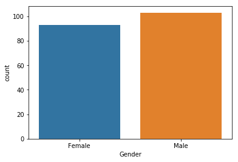

```python
# Graph to show gender distribution
sns.countplot(x='Gender',data=df)
```

----- ANALYSIS ON AGE FEATURE -----

```python
df.Age.value_counts()
```

```
20-25    181
25-30     15
Name: Age, dtype: int64
```

```python
##calculates the counts and percentage of AGE
k=df.Age.value_counts()
percent=df.Age.value_counts(normalize=True)
percent100=df.Age.value_counts(normalize=True).mul(100).astype(str) + '%'
pd.DataFrame({'Total':k,'%':percent100})
```

|  | Total | % |
| --- | --- | --- |
| 20-25 | 181 | 92.3469387755102% |
| 25-30 | 15 | 7.653061224489796% |

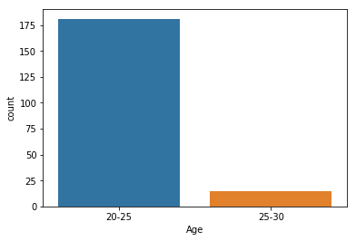

```python
# Graph to show age distribution
sns.countplot(x='Age', data=df)
```

----- (Conclusion) ----- Since the data doesn't have proper subdivision between the two mentioned distribution below. We will consider the age as whole subset with a range of 20-30

----- ANALYSIS ON OUTCOME FEATURE -----

```python
df.Outcome.value_counts()
```

```
Further learning    110
Good paying job      86
Name: Outcome, dtype: int64
```

```python
##calculates the counts and percentage of Outcome
k=df.Outcome.value_counts()
percent=df.Outcome.value_counts(normalize=True)
percent100=df.Outcome.value_counts(normalize=True).mul(100).astype(str) + '%'
pd.DataFrame({'Total':k,'%':percent100})
```

|  | Total | % |
| --- | --- | --- |
| Further learning | 110 | 56.12244897959183% |
| Good paying job | 86 | 43.87755102040816% |

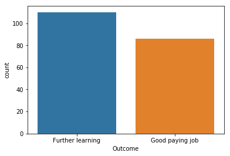

```python
# Graph to show outcome distribution
sns.countplot(x='Outcome', data=df)
```

----- GENERAL DESCRIPTION OF DATA (Such as description and datatypes)-----

```python
df.describe()
```

|  | SM-1 | SM-2 | SM-3 | SM-4 | SW-1 | SW-2 | SW-3 | SW-4 | SW-5 | SW-6 | ... | Em-1 | Em-2 | Em-3 | SR-1 | SR-2 | SR-3 | SR-4 | SR-6 | SR-7 | Total |
| --- | --- | --- | --- | --- | --- | --- | --- | --- | --- | --- | --- | --- | --- | --- | --- | --- | --- | --- | --- | --- | --- |
| count | 196.000000 | 196.000000 | 196.000000 | 196.000000 | 196.000000 | 196.000000 | 196.000000 | 196.000000 | 196.000000 | 196.000000 | ... | 196.000000 | 196.000000 | 196.000000 | 196.000000 | 196.000000 | 196.000000 | 196.000000 | 196.000000 | 196.000000 | 196.000000 |
| mean | 3.586735 | 3.693878 | 3.091837 | 2.586735 | 3.566327 | 3.693878 | 3.617347 | 3.321429 | 3.612245 | 3.836735 | ... | 3.515306 | 3.612245 | 3.193878 | 3.698980 | 3.270408 | 3.474490 | 3.658163 | 3.377551 | 2.887755 | 124.566327 |
| std | 0.769700 | 0.846206 | 0.972301 | 1.149193 | 0.917460 | 0.910431 | 0.923486 | 1.078342 | 0.866856 | 0.831358 | ... | 0.761086 | 0.824405 | 0.999058 | 0.953374 | 0.957208 | 0.902624 | 0.906096 | 0.976811 | 1.117531 | 9.243747 |
| min | 2.000000 | 2.000000 | 1.000000 | 1.000000 | 1.000000 | 1.000000 | 1.000000 | 1.000000 | 2.000000 | 1.000000 | ... | 1.000000 | 2.000000 | 1.000000 | 1.000000 | 1.000000 | 1.000000 | 2.000000 | 1.000000 | 1.000000 | 78.000000 |
| 25% | 3.000000 | 3.000000 | 2.000000 | 2.000000 | 3.000000 | 3.000000 | 3.000000 | 2.000000 | 3.000000 | 3.000000 | ... | 3.000000 | 3.000000 | 2.000000 | 3.000000 | 2.750000 | 3.000000 | 3.000000 | 3.000000 | 2.000000 | 118.000000 |
| 50% | 4.000000 | 4.000000 | 3.000000 | 2.000000 | 4.000000 | 4.000000 | 4.000000 | 4.000000 | 4.000000 | 4.000000 | ... | 4.000000 | 4.000000 | 3.000000 | 4.000000 | 3.000000 | 4.000000 | 4.000000 | 4.000000 | 3.000000 | 124.000000 |
| 75% | 4.000000 | 4.000000 | 4.000000 | 4.000000 | 4.000000 | 4.000000 | 4.000000 | 4.000000 | 4.000000 | 4.000000 | ... | 4.000000 | 4.000000 | 4.000000 | 4.000000 | 4.000000 | 4.000000 | 4.000000 | 4.000000 | 4.000000 | 132.000000 |
| max | 5.000000 | 5.000000 | 5.000000 | 5.000000 | 5.000000 | 5.000000 | 5.000000 | 5.000000 | 5.000000 | 5.000000 | ... | 5.000000 | 5.000000 | 5.000000 | 5.000000 | 5.000000 | 5.000000 | 5.000000 | 5.000000 | 5.000000 | 146.000000 |

8 rows × 37 columns

```python
df.dtypes
```

```
Gender     object
Age        object
Country    object
SM-1        int64
SM-2        int64
SM-3        int64
SM-4        int64
SW-1        int64
SW-2        int64
SW-3        int64
SW-4        int64
SW-5        int64
SW-6        int64
SW-7        int64
SW-8        int64
SW-9        int64
SW-10       int64
SW-11       int64
SS-1        int64
SS-2        int64
SS-3        int64
SS-4        int64
SS-5        int64
SS-6        int64
MT-1        int64
MT-2        int64
MT-3        int64
MT-4        int64
MT-5        int64
MT-6        int64
Em-1        int64
Em-2        int64
Em-3        int64
SR-1        int64
SR-2        int64
SR-3        int64
SR-4        int64
SR-6        int64
SR-7        int64
Total       int64
Outcome    object
dtype: object
```

## VISUALIZATION

### Hypothesis-1 (Total Empathy vs Gender)

```python
df_gen = df["Gender"]
# all the score of the empathy questions are combined for the individual
# Em-1 I always have negative/positive  impacts in someone's life.
# Em-2 I see people as good and well intentioned.
# Em-3 I normally think that I can easily get into the other’ shoes and can experience their feelings.
df_em = df["Em-1"]+df["Em-2"]+df["Em-3"]
# Converting two series into one dataframe
df_emp = pd.DataFrame({'Gender':df_gen,'EM':df_em})
df_emp.head()
```

|  | Gender | EM |
| --- | --- | --- |
| 0 | Female | 14 |
| 1 | Female | 8 |
| 2 | Female | 12 |
| 3 | Male | 10 |
| 4 | Female | 9 |

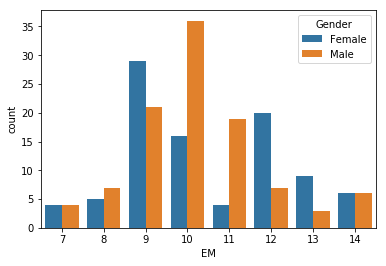

```python
sns.countplot(x='EM',hue='Gender',data=df_emp)
```

```python
##calculates the counts and percentage of Outcome
k=df_emp.EM.value_counts()
percent=df_emp.EM.value_counts(normalize=True)
percent100=df_emp.EM.value_counts(normalize=True).mul(100).astype(str) + '%'
pd.DataFrame({'Total':k,'%':percent100})
```

|  | Total | % |
| --- | --- | --- |
| 10 | 52 | 26.53061224489796% |
| 9 | 50 | 25.510204081632654% |
| 12 | 27 | 13.77551020408163% |
| 11 | 23 | 11.73469387755102% |
| 14 | 12 | 6.122448979591836% |
| 13 | 12 | 6.122448979591836% |
| 8 | 12 | 6.122448979591836% |
| 7 | 8 | 4.081632653061225% |

Conclusion A) As per the graph, highest score as well as the lowest score for empathy for both gender is same even though the value is not same no conclusion can be derived

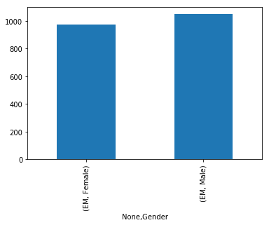

```python
DFGroup = df_emp.groupby(['Gender'])
DFGPlot = DFGroup.sum().unstack('Key').plot(kind='bar')
```

### Hypothesis-2 (Outcome vs Gender)

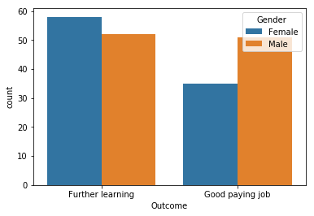

```python
sns.countplot(x='Outcome',hue='Gender', data=df)
```

### Hypothesis-3 (Stress in respondents)

```python
# all the score of the stress management questions in professional life are combined for the individual
# SM-3 I get burdened when some other person’s work is assigned to me.
# SM-4 I experience anxiety attacks or mental breakdown when workload increases suddenly.
df_stress = df['SM-3']+df['SM-4']
# Converting the above series into one dataframe
df_stress = pd.DataFrame({'SM':df_stress})
```

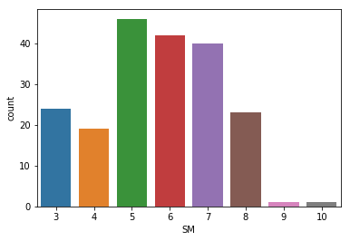

```python
# Max total=10 because of each of the compentent have 5 as max marks
sns.countplot(x='SM',data=df_stress)
```

```python
##calculates the counts and percentage of SM
k=df_stress.SM.value_counts()
percent=df_stress.SM.value_counts(normalize=True)
percent100=df_stress.SM.value_counts(normalize=True).mul(100).astype(str) + '%'
pd.DataFrame({'Total':k,'%':percent100})
```

|  | Total | % |
| --- | --- | --- |
| 5 | 46 | 23.46938775510204% |
| 6 | 42 | 21.428571428571427% |
| 7 | 40 | 20.408163265306122% |
| 3 | 24 | 12.244897959183673% |
| 8 | 23 | 11.73469387755102% |
| 4 | 19 | 9.693877551020408% |
| 10 | 1 | 0.5102040816326531% |
| 9 | 1 | 0.5102040816326531% |

Conclusion- from the graph as well as the percentage ratio respondents don't show dangerous amount of stress but its still think they are under stress (i.e 64%=23+21+20)

### Hypothesis-4 (Can respondents control their emotions or not.)

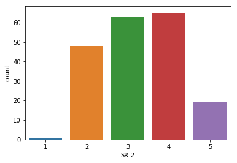

```python
# SR-2 I react immediately to a situation.
sns.countplot(x='SR-2',data=df)
```

```python
##calculates the counts and percentage of SR-2
k=df['SR-2'].value_counts()
percent=df['SR-2'].value_counts(normalize=True)
percent100=df['SR-2'].value_counts(normalize=True).mul(100).astype(str) + '%'
pd.DataFrame({'Total':k,'%':percent100})
```

|  | Total | % |
| --- | --- | --- |
| 4 | 65 | 33.16326530612245% |
| 3 | 63 | 32.142857142857146% |
| 2 | 48 | 24.489795918367346% |
| 5 | 19 | 9.693877551020408% |
| 1 | 1 | 0.5102040816326531% |